# Multilevel tutorial 4, part II

### Setup

```r
# Load packages
if(!require(lme4)){install.packages('lme4')}
```

```r
if(!require(ggplot2)){install.packages('ggplot2')}
require(ggplot2)
require(lme4)

# Source the inv.logit and logit functions for ease of use.
source('http://pastebin.com/raw.php?i=v1PDDYz7')
setwd('D:/files/teaching/2014multilevel/')
```

## Question 1

```r
stops <- read.table('4_stops.dat.txt', header=TRUE)
# Select only drug related crimes
stops <- stops[stops$crime == 4,]
```

After selecting for drug-related crimes, a remaining 225 rows of data remain.

## Question 2

```r
m0 <- glm(stops ~ 1, data=stops, family=poisson)
summary(m0)
```

```
##
## Call:
## glm(formula = stops ~ 1, family = poisson, data = stops)
##
## Deviance Residuals:
##     Min       1Q   Median       3Q      Max
## -11.550   -7.658   -3.391    3.793   25.380
##
## Coefficients:
##             Estimate Std. Error z value Pr(>|z|)
## (Intercept) 4.200238   0.008163   514.6   <2e-16 ***
## ---
## Signif. codes:  0 '***' 0.001 '**' 0.01 '*' 0.05 '.' 0.1 ' ' 1
##
## (Dispersion parameter for poisson family taken to be 1)
##
##     Null deviance: 14788  on 224  degrees of freedom
## Residual deviance: 14788  on 224  degrees of freedom
## AIC: 15976
##
## Number of Fisher Scoring iterations: 5
```

## Question 3

The estimated rate parameter of the Poisson distribution is , or $\lambda$, is 66.7. This is the grand mean of the number of stops in drug-related crimes; this you can see when running the following command:

```r
mean(stops$stops)
```

```
## [1] 66.70222
```

## Question 4

```r
m1 <- glm(stops ~ 1 + pop, data=stops, family=poisson)
summary(m1)
```

```
##
## Call:
## glm(formula = stops ~ 1 + pop, family = poisson, data = stops)
##
## Deviance Residuals:
##     Min       1Q   Median       3Q      Max
## -21.957   -6.912   -2.525    2.745   26.605
##
## Coefficients:
##              Estimate Std. Error z value Pr(>|z|)
## (Intercept) 3.857e+00  1.170e-02  329.53   <2e-16 ***
## pop         9.520e-06  1.945e-07   48.95   <2e-16 ***
## ---
## Signif. codes:  0 '***' 0.001 '**' 0.01 '*' 0.05 '.' 0.1 ' ' 1
##
## (Dispersion parameter for poisson family taken to be 1)
##
##     Null deviance: 14788  on 224  degrees of freedom
## Residual deviance: 12763  on 223  degrees of freedom
## AIC: 13953
##
## Number of Fisher Scoring iterations: 5
```

```r
anova(m1, m0, test='Chisq')
```

```
## Analysis of Deviance Table
##
## Model 1: stops ~ 1 + pop
## Model 2: stops ~ 1
##   Resid. Df Resid. Dev Df Deviance  Pr(>Chi)
## 1       223      12762
## 2       224      14788 -1  -2025.4 < 2.2e-16 ***
## ---
## Signif. codes:  0 '***' 0.001 '**' 0.01 '*' 0.05 '.' 0.1 ' ' 1
```

The summary for the model with the fixed effect of population indicates that population shows evidence that it matters in predicting the number of stops. Because this is the only parameter added, the model comparison test reflects this significance, where the model with the fixed effect of population performs better than the intercept-only model.

## Question 5

```
## stat_bin: binwidth defaulted to range/30. Use 'binwidth = x' to adjust this.
```

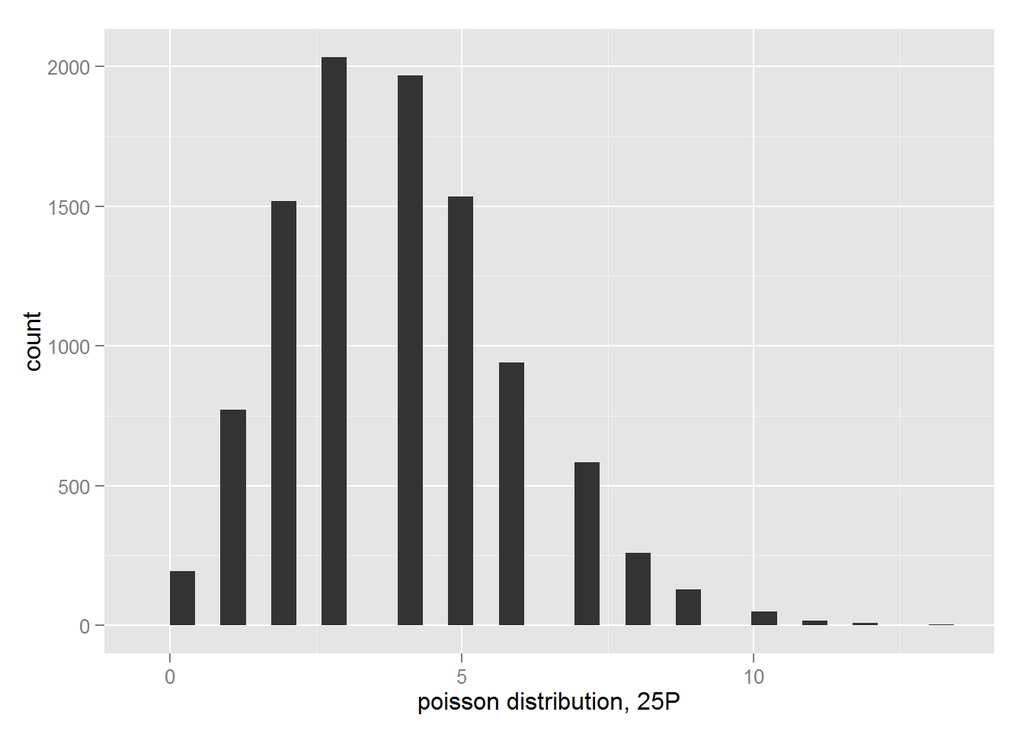

```r
qplot(rpois(10000, coef(m1)[1] + coef(m1)[2] * summary(stops$pop)[2]),
      xlab='poisson distribution, 25P')
```

```
## stat_bin: binwidth defaulted to range/30. Use 'binwidth = x' to adjust this.
```

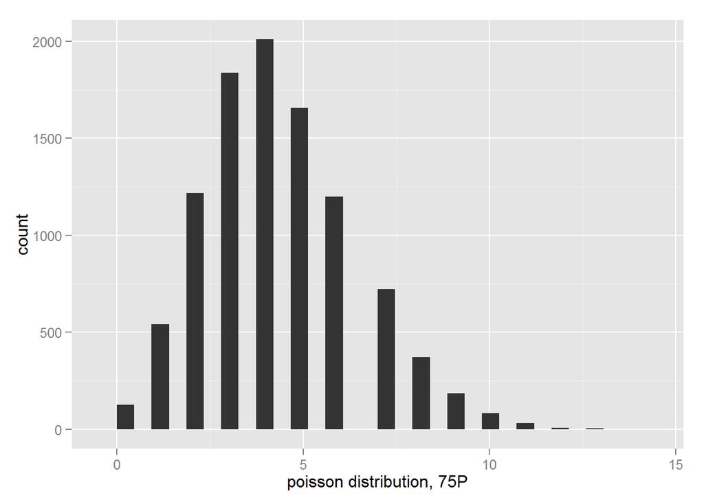

```r
qplot(rpois(10000, coef(m1)[1] + coef(m1)[2] * summary(stops$pop)[5]),
      xlab='poisson distribution, 75P')
```

## Question 6

```r
m2 <- glmer(stops ~ 1 + (1 | precinct), data=stops, family=poisson)
summary(m2)
```

```
## Generalized linear mixed model fit by maximum likelihood (Laplace
##   Approximation) [glmerMod]
##  Family: poisson  ( log )
## Formula: stops ~ 1 + (1 | precinct)
##    Data: stops
##
##      AIC      BIC   logLik deviance df.resid
##  10729.8  10736.6  -5362.9  10725.8      223
##
## Scaled residuals:
##     Min      1Q  Median      3Q     Max
## -11.911  -4.770  -1.466   3.608  17.879
##
## Random effects:
##  Groups   Name        Variance Std.Dev.
##  precinct (Intercept) 0.5018   0.7084
## Number of obs: 225, groups:  precinct, 75
##
## Fixed effects:
##             Estimate Std. Error z value Pr(>|z|)
## (Intercept)  3.98402    0.08246   48.31   <2e-16 ***
## ---
## Signif. codes:  0 '***' 0.001 '**' 0.01 '*' 0.05 '.' 0.1 ' ' 1
```

## Question 7

```r
m3 <- glmer(stops ~ 1 + pop + (1 | precinct), data=stops, family=poisson)
summary(m3)
```

```
## Generalized linear mixed model fit by maximum likelihood (Laplace
##   Approximation) [glmerMod]
##  Family: poisson  ( log )
## Formula: stops ~ 1 + pop + (1 | precinct)
##    Data: stops
##
##      AIC      BIC   logLik deviance df.resid
##   8243.8   8254.0  -4118.9   8237.8      222
##
## Scaled residuals:
##      Min       1Q   Median       3Q      Max
## -12.5954  -4.0223  -0.9129   3.4103  20.3724
##
## Random effects:
##  Groups   Name        Variance Std.Dev.
##  precinct (Intercept) 0.5814   0.7625
## Number of obs: 225, groups:  precinct, 75
##
## Fixed effects:
##              Estimate Std. Error z value Pr(>|z|)
## (Intercept) 3.458e+00  1.024e-01   33.78   <2e-16 ***
## pop         1.436e-05  1.248e-06   11.51   <2e-16 ***
## ---
## Signif. codes:  0 '***' 0.001 '**' 0.01 '*' 0.05 '.' 0.1 ' ' 1
##
## Correlation of Fixed Effects:
##     (Intr)
## pop -0.500
```

```r
anova(m3, m2, test='Chisq')
```

```
## Data: stops
## Models:
## m2: stops ~ 1 + (1 | precinct)
## m3: stops ~ 1 + pop + (1 | precinct)
##    Df     AIC   BIC  logLik deviance Chisq Chi Df Pr(>Chisq)
## m2  2 10729.8 10737 -5362.9  10725.8
## m3  3  8243.8  8254 -4118.9   8237.8  2488      1  < 2.2e-16 ***
## ---
## Signif. codes:  0 '***' 0.001 '**' 0.01 '*' 0.05 '.' 0.1 ' ' 1
```

The model with the fixed effect performs significantly better.

## Question 8

```r
m4 <- glmer(stops ~ 1 + pop + eth + (1 | precinct), data=stops, family=poisson)
summary(m4)
```

```
## Generalized linear mixed model fit by maximum likelihood (Laplace
##   Approximation) [glmerMod]
##  Family: poisson  ( log )
## Formula: stops ~ 1 + pop + eth + (1 | precinct)
##    Data: stops
##
##      AIC      BIC   logLik deviance df.resid
##   4799.4   4813.1  -2395.7   4791.4      221
##
## Scaled residuals:
##      Min       1Q   Median       3Q      Max
## -11.2280  -2.7258  -0.4901   2.2373  14.6453
##
## Random effects:
##  Groups   Name        Variance Std.Dev.
##  precinct (Intercept) 0.6008   0.7751
## Number of obs: 225, groups:  precinct, 75
##
## Fixed effects:
##               Estimate Std. Error z value Pr(>|z|)
## (Intercept)  4.495e+00  1.009e-01   44.55   <2e-16 ***
## pop          2.053e-05  1.185e-06   17.32   <2e-16 ***
## eth         -6.837e-01  1.197e-02  -57.13   <2e-16 ***
## ---
## Signif. codes:  0 '***' 0.001 '**' 0.01 '*' 0.05 '.' 0.1 ' ' 1
##
## Correlation of Fixed Effects:
##     (Intr) pop
## pop -0.406
## eth -0.042 -0.343
```

```r
anova(m4, m2, test='Chisq')
```

```
## Data: stops
## Models:
## m2: stops ~ 1 + (1 | precinct)
## m4: stops ~ 1 + pop + eth + (1 | precinct)
##    Df     AIC     BIC  logLik deviance  Chisq Chi Df Pr(>Chisq)
## m2  2 10729.8 10736.6 -5362.9  10725.8
## m4  4  4799.4  4813.1 -2395.7   4791.4 5934.4      2  < 2.2e-16 ***
## ---
## Signif. codes:  0 '***' 0.001 '**' 0.01 '*' 0.05 '.' 0.1 ' ' 1
```

The model with the fixed effects fits significantly better than the random-intercept-only model.

## Question 9

Based on the results from the previous model, the parameter is highest, ceteris paribus, for ethnicity 1, i.e., black.

## Question 10

Variance in the precincts is highly equal for both model 3 and model 4. It thus seems that the variance of stops due to precincts, and due to ethnicity are distinct.